# Port Phillip Bay seawater temps

The temperature records are satellite sea surface temperatures. They are provided in several places, and what’s here comes from [NOAA](https://https://coastwatch.pfeg.noaa.gov/erddap/griddap/nesdisGeoPolarSSTN5NRT.html), presented as °C in the dataset *NOAA_DHW*. They come from grids 0.05° x 0.05°, corresponding to 5km x 5km. They can be viewed interactively, but it’s not easy to look at multi-year time series or site comparisons.

The closest grid cell to Williamstown beach is centred on Lon. 144.875, Lat. -37.875. Two other snorkelling/diving spots are included; the SE corner of the bay (Blairgowrie, Rye, etc.) is 144.775, -38.375, and just outside Western Port (near Flinders pier) is 145.025, -38.475.

## Williamstown time series

#### Current year, with last year for an immediate comparison

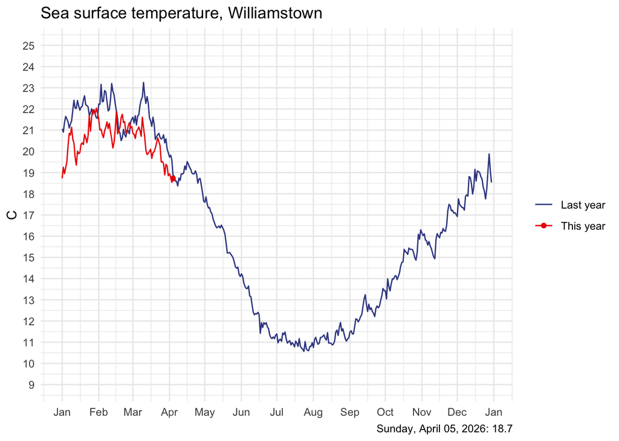

#### Multi-year plots

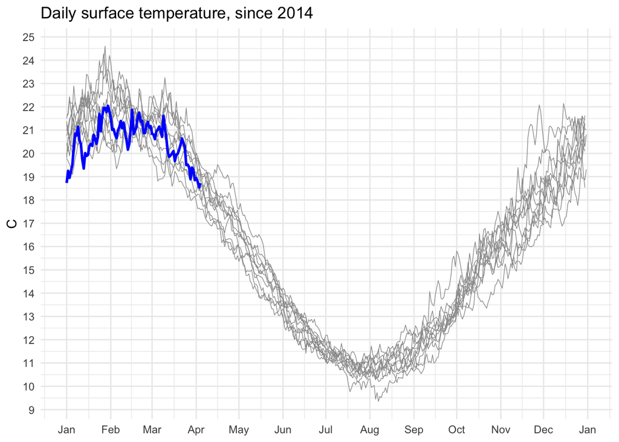

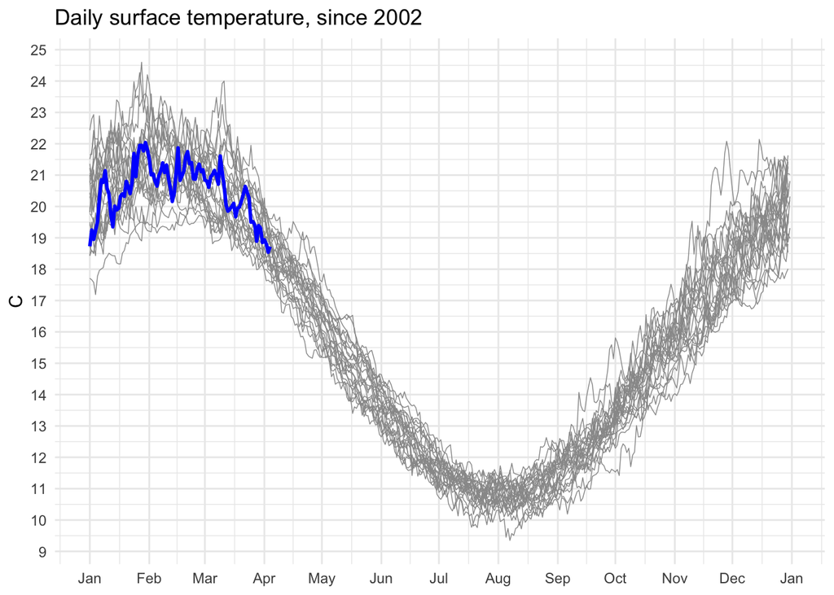

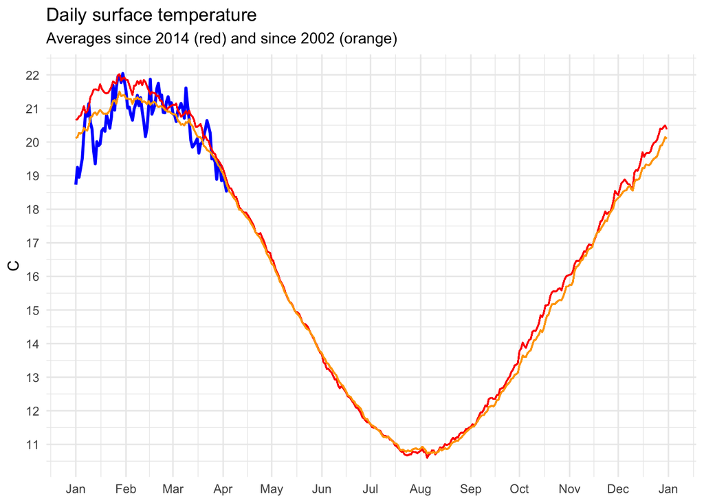

## Three places of interest to divers and snorkellers

Open coast sites, such as Flinders, don’t get as warm or as cold as those near the top of Port Phillip Bay (Williamstown). Places near the entrance of the bay (Blairgowrie) are intermediate, but closer to open ocean.

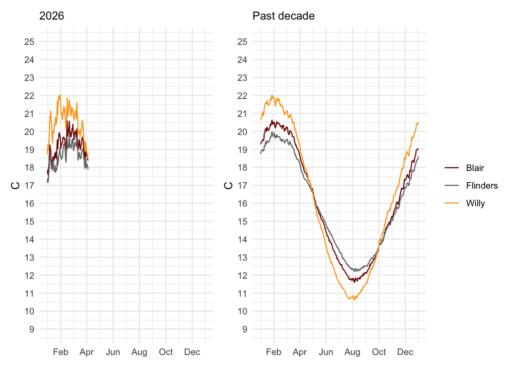

### Temperature contour map

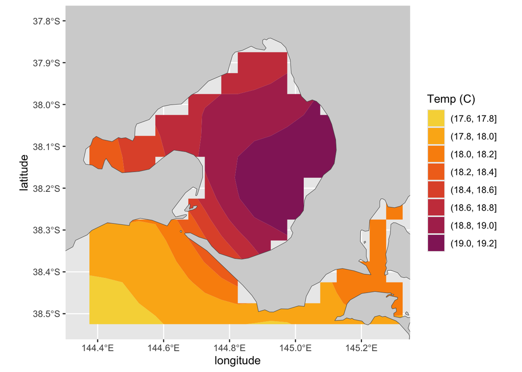